# Travel With US

### Observations:

1. Out of all the people who bought the Travel Package:
   - 52.9% preferred 3 star properties
   - 19.8% preferred 4 star properties
   - 27.1% preferred 5 star properties.
2. From the stats, it shows that 3 star properties are the most preferred ones.

```
Count of ProdTaken by MaritalStatus

MaritalStatus  ProdTaken
Divorced       0             821
               1             123
Married        0            1999
               1             326
Single         0             610
               1             302
Unmarried      0             516
               1             166
Name: ProdTaken, dtype: int64
```

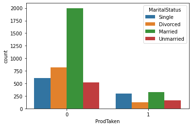

```python
# ProdTaken vs MaritalStatus
print('Count of ProdTaken by MaritalStatus')
print('  ')
print(tourismData.groupby('MaritalStatus')['ProdTaken'].value_counts(ascending=False))
sns.countplot(x=tourismData['ProdTaken'],hue=tourismData['MaritalStatus']);
```

### Observations:

1. Out of all the people who bought the Travel package:
   - 13.4% are Divorced
   - 35.5% are Married
   - 32.9% are Single
   - 18.1% are Unmarried.
2. Most of the people who bought the Travel Package are either Married or Single.

```
Count of ProdTaken by NumberOfTrips

NumberOfTrips  ProdTaken
1.0            0             502
               1             112
2.0            0            1157
               1             299
3.0            0             987
               1             229
4.0            0             415
               1              60
5.0            0             394
               1              62
6.0            0             257
               1              64
7.0            0             156
               1              60
8.0            0              76
               1              29
19.0           1               1
20.0           1               1
21.0           0               1
22.0           0               1
Name: ProdTaken, dtype: int64
```

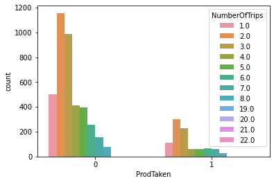

```python
# ProdTaken vs NumberOfTrips
print('Count of ProdTaken by NumberOfTrips')
print('  ')
print(tourismData.groupby('NumberOfTrips')['ProdTaken'].value_counts(ascending=False))

sns.countplot(x=tourismData['ProdTaken'],hue=tourismData['NumberOfTrips']);
```

### Observations:

```
Count of ProdTaken by NumberOfPersonVisiting

Passport  ProdTaken
0         0            3018
          1             423
1         0             928
          1             494
Name: ProdTaken, dtype: int64
```

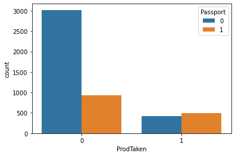

```python
# ProdTaken vs Passport
print('Count of ProdTaken by NumberOfPersonVisiting')
print('  ')
print(tourismData.groupby('Passport')['ProdTaken'].value_counts(ascending=False))
sns.countplot(x=tourismData['ProdTaken'],hue=tourismData['Passport']);
```

### Observations:

1. Out of all the people who got the travel package, 53% have their passport and 47% do not have a passport.
2. Based on this insight, the travel company should promote both domestic and international travel packages.

```
Count of ProdTaken by PitchSatisfactionScore

PitchSatisfactionScore  ProdTaken
1                       0             794
                        1             143
2                       0             495
                        1              88
3                       0            1152
                        1             314
4                       0             748
                        1             162
5                       0             757
                        1             210
Name: ProdTaken, dtype: int64
```

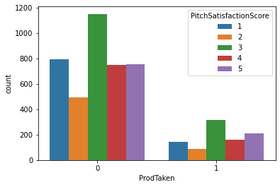

```python
# ProdTaken vs PitchSatisfactionScore
print('Count of ProdTaken by PitchSatisfactionScore')
print('  ')
print(tourismData.groupby('PitchSatisfactionScore')['ProdTaken'].value_counts(ascending=False))
sns.countplot(x=tourismData['ProdTaken'],hue=tourismData['PitchSatisfactionScore']);
```

### Observations:

1. Out of all the people who bought the Travel package, 34.2% of them gave the PitchSatisfationScore of 3, followed by 22.9% who gave a score of 5, followed by 17% who gave a score of 4.
2. Only 9.5% gave a score of 2 and 15.5% gave a score of 1.

```
Count of ProdTaken by OwnCar

OwnCar  ProdTaken
0       0            1486
        1             359
1       0            2460
        1             558
Name: ProdTaken, dtype: int64
```

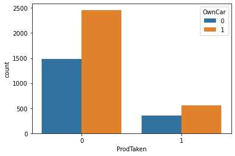

```python
# ProdTaken vs OwnCar
print('Count of ProdTaken by OwnCar')
print('  ')
print(tourismData.groupby('OwnCar')['ProdTaken'].value_counts(ascending=False))

sns.countplot(x=tourismData['ProdTaken'],hue=tourismData['OwnCar']);
```

### Observations:

1. Out of all the people who bought the Travel Package, 558 (60%) have their own car but 359 (39%) do not own a car.
2. The travel company can look at including car/ transport services to-from airport for the people using the travel package

```
Count of ProdTaken by NumberOfChildrenVisiting

NumberOfChildrenVisiting  ProdTaken
0.0                       0             870
                          1             200
1.0                       0            1737
                          1             398
2.0                       0            1080
                          1             253
3.0                       0             259
                          1              66
Name: ProdTaken, dtype: int64
```

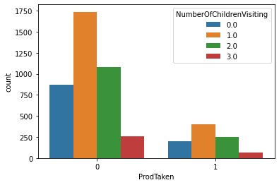

```python
# ProdTaken vs NumberOfChildrenVisiting
print('Count of ProdTaken by NumberOfChildrenVisiting')
print('  ')
print(tourismData.groupby('NumberOfChildrenVisiting')['ProdTaken'].value_counts(ascending=False))
sns.countplot(x=tourismData['ProdTaken'],hue=tourismData['NumberOfChildrenVisiting']);
```

### Observations:

1. Out of all the people who for the information on Travel Package and bought the Travel Package, 43.4% will have 1 child visiting with them, 27.5% will have 2 children visiting with them, 21% will not have any child visiting with them and 7.2% will have 3 children visiting with them.
2. Most of the people who buy the travel package, have mostly 1 child traveling with them.

```
Count of ProdTaken by Designation

Designation     ProdTaken
AVP             0             322
                1              20
Executive       0            1283
                1             549
Manager         0            1513
                1             204
Senior Manager  0             618
                1             124
VP              0             210
                1              20
Name: ProdTaken, dtype: int64
```

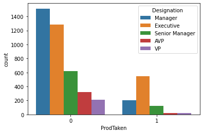

```python
# ProdTaken vs Designation
print('Count of ProdTaken by Designation')
print('  ')
print(tourismData.groupby('Designation')['ProdTaken'].value_counts(ascending=False))

sns.countplot(x=tourismData['ProdTaken'],hue=tourismData['Designation']);
```

### Observations:

1. Out of all the people who got the product information and ended up buying the travel package, 2% are AVP, 59.8% are Executives, 22.2% are Managers, 13.5% are Senior Managers and 2% are VPs in their organization.
2. Most of the people who bought the Travel pacakge are Executives.

```python
df=tourismData.copy()
tourismData.info()
```

```
<class 'pandas.core.frame.DataFrame'>
Int64Index: 4863 entries, 0 to 4887
Data columns (total 19 columns):
 #   Column                    Non-Null Count  Dtype
---  ------                    --------------  -----
 0   ProdTaken                 4863 non-null   int64
 1   Age                       4863 non-null   float64
 2   TypeofContact             4863 non-null   object
 3   CityTier                  4863 non-null   int64
 4   DurationOfPitch           4863 non-null   float64
 5   Occupation                4863 non-null   object
 6   Gender                    4863 non-null   object
 7   NumberOfPersonVisiting    4863 non-null   int64
 8   NumberOfFollowups         4863 non-null   float64
 9   ProductPitched            4863 non-null   object
 10  PreferredPropertyStar     4863 non-null   float64
 11  MaritalStatus             4863 non-null   object
 12  NumberOfTrips             4863 non-null   float64
 13  Passport                  4863 non-null   int64
 14  PitchSatisfactionScore    4863 non-null   int64
 15  OwnCar                    4863 non-null   int64
 16  NumberOfChildrenVisiting  4863 non-null   float64
 17  Designation               4863 non-null   object
 18  MonthlyIncome             4863 non-null   float64
dtypes: float64(7), int64(6), object(6)
memory usage: 888.9+ KB
```

## Perform One Hot encoding for the object columns

```python
oneHotCols=["TypeofContact","Occupation","Gender","ProductPitched","MaritalStatus","Designation"]
```

```python
tourismData=pd.get_dummies(tourismData, columns=oneHotCols)
```

## Split the data into train and test sets

- When data (classification) exhibit a significant imbalance in the distribution of the target classes, it is good to use stratified sampling to ensure that relative class frequencies are approximately preserved in train and test sets.
- This is done by setting the `stratify` parameter to target variable in the train_test_split function.

```python
X = tourismData.drop("ProdTaken" , axis=1)
y = tourismData.pop("ProdTaken")
```

```python
X_train, X_test, y_train, y_test = train_test_split(X, y, test_size=.30, random_state=1,stratify=y)
```

```python
print("{0:0.2f}% data is in training set".format((len(X_train)/len(tourismData.index)) * 100))
print("{0:0.2f}% data is in test set".format((len(X_test)/len(tourismData.index)) * 100))
print("")
print("Original ProdTaken True Values    : {0} ({1:0.2f}%)".format(len(df.loc[df['ProdTaken'] == 1]), (len(df.loc[df['ProdTaken'] == 1])/len(df.index)) * 100))
print("Original ProdTaken False Values   : {0} ({1:0.2f}%)".format(len(df.loc[df['ProdTaken'] == 0]), (len(df.loc[df['ProdTaken'] == 0])/len(df.index)) * 100))
print("")
print("Training ProdTaken True Values    : {0} ({1:0.2f}%)".format(len(y_train[y_train[:] == 1]), (len(y_train[y_train[:] == 1])/len(y_train)) * 100))
print("Training ProdTaken False Values   : {0} ({1:0.2f}%)".format(len(y_train[y_train[:] == 0]), (len(y_train[y_train[:] == 0])/len(y_train)) * 100))
print("")
print("Test ProdTaken True Values        : {0} ({1:0.2f}%)".format(len(y_test[y_test[:] == 1]), (len(y_test[y_test[:] == 1])/len(y_test)) * 100))
print("Test ProdTaken False Values       : {0} ({1:0.2f}%)".format(len(y_test[y_test[:] == 0]), (len(y_test[y_test[:] == 0])/len(y_test)) * 100))
print("")
```

```
70.00% data is in training set
30.00% data is in test set

Original ProdTaken True Values    : 917 (18.86%)
Original ProdTaken False Values   : 3946 (81.14%)

Training ProdTaken True Values    : 642 (18.86%)
Training ProdTaken False Values   : 2762 (81.14%)

Test ProdTaken True Values        : 275 (18.85%)
Test ProdTaken False Values       : 1184 (81.15%)
```

**Before building the model, let's create functions to calculate different metrics- Accuracy, Recall and Precision and plot the confusion matrix.**

```python
## Function to create confusion matrix
def make_confusion_matrix(model,y_actual,labels=[1, 0]):
    '''
    model : classifier to predict values of X
    y_actual : ground truth

    '''
    y_predict = model.predict(X_test)
    cm=metrics.confusion_matrix( y_actual, y_predict, labels=[0, 1])
    df_cm = pd.DataFrame(cm, index = [i for i in ["Actual - No","Actual - Yes"]],
                  columns = [i for i in ['Predicted - No','Predicted - Yes']])
    group_counts = ["{0:0.0f}".format(value) for value in
                cm.flatten()]
    group_percentages = ["{0:.2%}".format(value) for value in
                         cm.flatten()/np.sum(cm)]
    labels = [f"{v1}\n{v2}" for v1, v2 in
              zip(group_counts,group_percentages)]
    labels = np.asarray(labels).reshape(2,2)
    plt.figure(figsize = (10,7))
    sns.heatmap(df_cm, annot=labels,fmt='')
    plt.ylabel('True label')
    plt.xlabel('Predicted label')
```

```python
##  Function to calculate different metric scores of the model - Accuracy, Recall and Precision
def get_metrics_score(model,flag=True):
    '''
    model : classifier to predict values of X

    '''
    # defining an empty list to store train and test results
    score_list=[]

    #Predicting on train and tests
    pred_train = model.predict(X_train)
    pred_test = model.predict(X_test)

    #Accuracy of the model
    train_acc = model.score(X_train,y_train)
    test_acc = model.score(X_test,y_test)

    #Recall of the model
    train_recall = metrics.recall_score(y_train,pred_train)
    test_recall = metrics.recall_score(y_test,pred_test)

    #Precision of the model
    train_precision = metrics.precision_score(y_train,pred_train)
    test_precision = metrics.precision_score(y_test,pred_test)

    score_list.extend((train_acc,test_acc,train_recall,test_recall,train_precision,test_precision))

    # If the flag is set to True then only the following print statements will be dispayed. The default value is set to True.
    if flag == True:
        print("Accuracy on training set : ",model.score(X_train,y_train))
        print("Accuracy on test set : ",model.score(X_test,y_test))
        print("Recall on training set : ",metrics.recall_score(y_train,pred_train))
        print("Recall on test set : ",metrics.recall_score(y_test,pred_test))
        print("Precision on training set : ",metrics.precision_score(y_train,pred_train))
        print("Precision on test set : ",metrics.precision_score(y_test,pred_test))

    return score_list # returning the list with train and test scores
```

## Bagging Classifiers

- We are going to build 2 ensemble models here - Bagging Classifier and Random Forest Classifier.
- First, let's build these models with default parameters and then use hyperparameter tuning to optimize the model performance.
- We will calculate all three metrics - Accuracy, Precision and Recall but the metric of interest here is recall.
- `Recall` - It gives the ratio of True positives to Actual positives, so high Recall implies low false negatives, i.e. low chances of predicting a customer as non customer.

```python
#base_estimator for bagging classifier is a decision tree by default
bagging_estimator=BaggingClassifier(random_state=1)
bagging_estimator.fit(X_train,y_train)
```

```
BaggingClassifier(random_state=1)
```

```python
#Using above defined function to get accuracy, recall and precision on train and test set
bagging_estimator_score=get_metrics_score(bagging_estimator)
```

```
Accuracy on training set :  0.9923619271445359
Accuracy on test set :  0.910212474297464
Recall on training set :  0.9595015576323987
Recall on test set :  0.6254545454545455
Precision on training set :  1.0
Precision on test set :  0.86
```

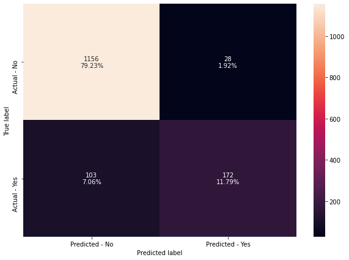

```python
make_confusion_matrix(bagging_estimator,y_test)
```

### Random Forest Classifier

```python
#Train the random forest classifier
rf_estimator=RandomForestClassifier(random_state=1)
rf_estimator.fit(X_train,y_train)
```

```
RandomForestClassifier(random_state=1)
```

```python
#Using above defined function to get accuracy, recall and precision on train and test set
rf_estimator_score=get_metrics_score(rf_estimator)
```

```
Accuracy on training set :  1.0
Accuracy on test set :  0.9191226867717615
Recall on training set :  1.0
Recall on test set :  0.6145454545454545
Precision on training set :  1.0
Precision on test set :  0.9337016574585635
```

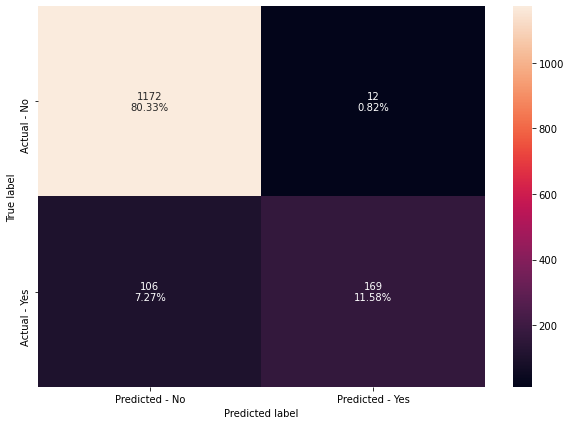

```python
make_confusion_matrix(rf_estimator,y_test)
```

**With default parameters:**

```python
dtree=DecisionTreeClassifier(random_state=1)
dtree.fit(X_train,y_train)
```

```
DecisionTreeClassifier(random_state=1)
```

```python
dtree_score=get_metrics_score(dtree)
```

```
Accuracy on training set :  1.0
Accuracy on test set :  0.890335846470185
Recall on training set :  1.0
Recall on test set :  0.7090909090909091
Precision on training set :  1.0
Precision on test set :  0.7090909090909091
```

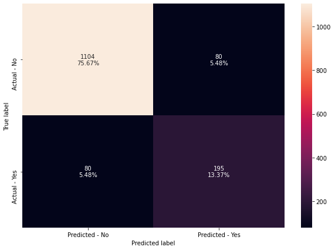

```python
make_confusion_matrix(dtree,y_test)
```

### Now let's try Hypertuning on Bagging, Random Forest and Decision Tree classifiers.

### Bagging Classifier Hypertuning

```python
# Choose the type of classifier.
# Using default base_estimator (Decision Tree)
# Using default value of bootstrap (True), get samples by replacement.
# Using default value of bootstrap_features (False).
# Using default value of oob_score (False)

bagging_estimator_tuned = BaggingClassifier(random_state=1)

# Grid of parameters to choose from
parameters = {'max_samples': [0.7,0.8,0.9,1],
              'max_features': [0.7,0.8,0.9,1],
              'n_estimators' : [50,60,70,90,100,150],
             }

# Type of scoring used to compare parameter combinations
acc_scorer = metrics.make_scorer(metrics.recall_score)

# Run the grid search
grid_obj = GridSearchCV(bagging_estimator_tuned, parameters, scoring=acc_scorer,cv=5)
grid_obj = grid_obj.fit(X_train, y_train)

# Set the clf to the best combination of parameters
bagging_estimator_tuned = grid_obj.best_estimator_

# Fit the best algorithm to the data.
bagging_estimator_tuned.fit(X_train, y_train)
```

```
BaggingClassifier(max_features=0.9, max_samples=0.9, n_estimators=100,
                  random_state=1)
```

### Observations:

1. We will be using hypertuned bagging classifier with max_feature=0.9, max_samples=0.9 and n_estimators=100 **Let's check different metrics for bagging classifier with best hyperparameters and build a confusion matrix.**

```python
#Using above defined function to get accuracy, recall and precision on train and test set
bagging_estimator_tuned_score=get_metrics_score(bagging_estimator_tuned)
```

```
Accuracy on training set :  1.0
Accuracy on test set :  0.9348869088416724
Recall on training set :  1.0
Recall on test set :  0.7054545454545454
Precision on training set :  1.0
Precision on test set :  0.9326923076923077
```

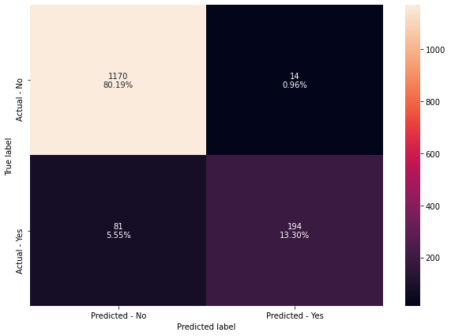

```python
make_confusion_matrix(bagging_estimator_tuned,y_test)
```

### Insights Bagging Classifier vs Hypertuned Bagging Classifier

- We can see that train and test accuracy for bagging classifier after hypertuning has increased.
- Training and Test Recall has increased after Hypertuning.
- Training Precision remained same for hypertuned and non hypertuned bagging classifier but Test Precision has increased for hypertuned bagging classifier.
- The confusion matrix shows that the hypertuned model is better at identifying True positives and True negatives after hypertuning, that is identify the customers who will buy the travel package and who won't.
- The hypertuned model is also better False Negatives and False Positives.

### Random Forest Classifier Hypertuning

Hyperparameters for Random Forest classifier are:

- n_estimators: The number of trees in the forest, default = 100.
- max_features: The number of features to consider when looking for the best split.
- class_weight: Weights associated with classes in the form {class_label: weight}.If not given, all classes are supposed to have weight one.
- bootstrap: Whether bootstrap samples are used when building trees. If False, the entire dataset is used to build each tree, default=True.
- max_samples: If bootstrap is True, then the number of samples to draw from X to train each base estimator. If None (default), then draw N samples, where N is the number of observations in the train data.
- oob_score: Whether to use out-of-bag samples to estimate the generalization accuracy, default=False.

```python
# RF- Hypertuned
rf_estimator_tuned = RandomForestClassifier(random_state=1)

# Grid of parameters to choose from
## add from article
parameters = {"n_estimators": [150,200,250],
    "min_samples_leaf": np.arange(5, 10),
    "max_features": np.arange(0.2, 0.7, 0.1),
    "max_samples": np.arange(0.3, 0.7, 0.1)
             }

# Type of scoring used to compare parameter combinations
acc_scorer = metrics.make_scorer(metrics.recall_score)

# Run the grid search
grid_obj = GridSearchCV(rf_estimator_tuned, parameters, scoring=acc_scorer,cv=5)
grid_obj = grid_obj.fit(X_train, y_train)

# Set the clf to the best combination of parameters
rf_estimator_tuned = grid_obj.best_estimator_

# Fit the best algorithm to the data.
rf_estimator_tuned.fit(X_train, y_train)
```

```
RandomForestClassifier(max_features=0.6000000000000001,
                       max_samples=0.6000000000000001, min_samples_leaf=5,
                       n_estimators=200, random_state=1)
```

```python
#Using above defined function to get accuracy, recall and precision on train and test set
rf_estimator_tuned_score=get_metrics_score(rf_estimator_tuned)
```

```
Accuracy on training set :  0.9112808460634547
Accuracy on test set :  0.8773132282385195
Recall on training set :  0.5529595015576324
Recall on test set :  0.4072727272727273
Precision on training set :  0.9594594594594594
Precision on test set :  0.875
```

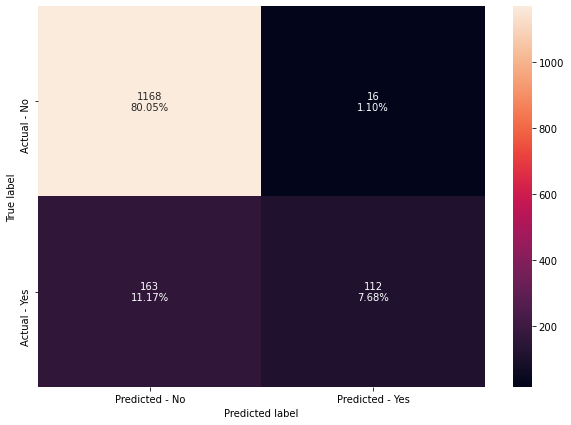

```python
make_confusion_matrix(rf_estimator_tuned,y_test)
```

### Let's try using class_weights for random forest:

- The random forest classifier's performance is ok after hyperparameterization but not great. This may be due to the fact that the classes are imbalanced with 81.14% non-customers and 18.86% customers.
- We should make the model aware that the class of interest here is 'ProdTaken'.
- We can do so by passing the parameter `class_weights` available for random forest. This parameter is not available for the bagging classifier.
- class_weight specifies the weights associated with classes in the form {class_label: weight}. If not given, all classes are supposed to have weight one.
- We can choose class_weights={0:0.2,1:0.8} because that is the original imbalance in our data.

```python
# Choose the type of classifier.
rf_estimator_weighted = RandomForestClassifier(random_state=1)

# Grid of parameters to choose from
## add from article
parameters = {
    "class_weight": [{0: 0.2, 1: 0.8}],
    "n_estimators": [100,150,200,250],
    "min_samples_leaf": np.arange(5, 10),
    "max_features": np.arange(0.2, 0.7, 0.1),
    "max_samples": np.arange(0.3, 0.7, 0.1),
}

# Type of scoring used to compare parameter combinations
acc_scorer = metrics.make_scorer(metrics.recall_score)

# Run the grid search
grid_obj = GridSearchCV(rf_estimator_weighted, parameters, scoring=acc_scorer,cv=5)
grid_obj = grid_obj.fit(X_train, y_train)

# Set the clf to the best combination of parameters
rf_estimator_weighted = grid_obj.best_estimator_

# Fit the best algorithm to the data.
rf_estimator_weighted.fit(X_train, y_train)
```

```
RandomForestClassifier(class_weight={0: 0.2, 1: 0.8},
                       max_features=0.6000000000000001,
                       max_samples=0.6000000000000001, min_samples_leaf=9,
                       n_estimators=250, random_state=1)
```

```python
#Using above defined function to get accuracy, recall and precision on train and test set
rf_estimator_weighted_score=get_metrics_score(rf_estimator_weighted)
```

```
Accuracy on training set :  0.8998237367802585
Accuracy on test set :  0.8608636052090473
Recall on training set :  0.8193146417445483
Recall on test set :  0.6690909090909091
Precision on training set :  0.7003994673768309
Precision on test set :  0.6216216216216216
```

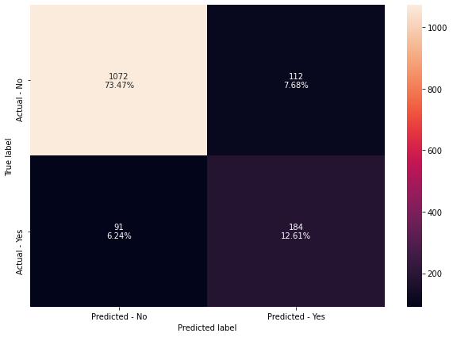

```python
make_confusion_matrix(rf_estimator_weighted,y_test)
```

### Decision Tree Tuned

```python
# Choose the type of classifier.
dtree_tuned = DecisionTreeClassifier(random_state=1)

# Grid of parameters to choose from
parameters = {'max_depth': list(np.arange(2,20)) + [None],
              'min_samples_leaf': [1, 3, 5, 7, 10],
              'max_leaf_nodes' : [2, 3, 5, 10, 15] + [None],
              'min_impurity_decrease': [0.001, 0.01, 0.1, 0.0]
             }

# Type of scoring used to compare parameter combinations
acc_scorer = metrics.make_scorer(metrics.recall_score)

# Run the grid search
grid_obj = GridSearchCV(dtree_tuned, parameters, scoring=acc_scorer,cv=5)
grid_obj = grid_obj.fit(X_train, y_train)

# Set the clf to the best combination of parameters
dtree_tuned = grid_obj.best_estimator_

# Fit the best algorithm to the data.
dtree_tuned.fit(X_train, y_train)
```

```
DecisionTreeClassifier(max_depth=16, random_state=1)
```

```python
dtree_tuned_score=get_metrics_score(dtree_tuned)
```

```
Accuracy on training set :  0.9952996474735605
Accuracy on test set :  0.8917066483893078
Recall on training set :  0.9750778816199377
Recall on test set :  0.6836363636363636
Precision on training set :  1.0
Precision on test set :  0.7258687258687259
```

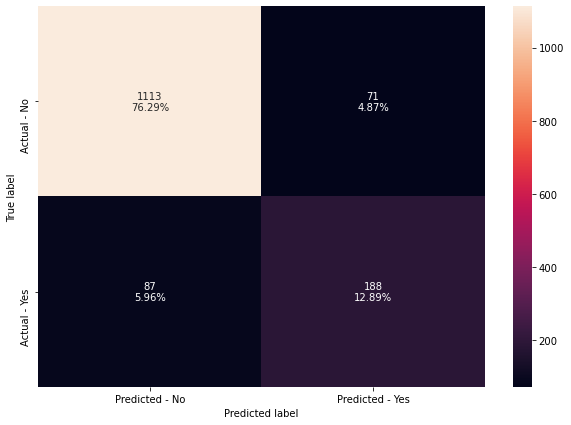

```python
make_confusion_matrix(dtree_tuned,y_test)
```

### Comparing all models till now

```python
# defining list of models
models = [bagging_estimator,bagging_estimator_tuned,rf_estimator,rf_estimator_tuned,
          rf_estimator_weighted,dtree,dtree_tuned]

# defining empty lists to add train and test results
acc_train = []
acc_test = []
recall_train = []
recall_test = []
precision_train = []
precision_test = []

# looping through all the models to get the accuracy, precall and precision scores
for model in models:
    j = get_metrics_score(model,False)
    acc_train.append(np.round(j[0],2))
    acc_test.append(np.round(j[1],2))
    recall_train.append(np.round(j[2],2))
    recall_test.append(np.round(j[3],2))
    precision_train.append(np.round(j[4],2))
    precision_test.append(np.round(j[5],2))
```

## Comparison Frame for Bagging Classifiers

```python
comparison_frame = pd.DataFrame({'Model':['Bagging classifier with default parameters','Tuned Bagging Classifier', 'Random Forest with deafult parameters',
                                         'Tuned Random Forest Classifier','Random Forest with class_weights','Decision Tree','Decision Tree Tuned'],
                                          'Train_Accuracy': acc_train,'Test_Accuracy': acc_test,
                                          'Train_Recall':recall_train,'Test_Recall':recall_test,
                                          'Train_Precision':precision_train,'Test_Precision':precision_test})
comparison_frame
```

|  | Model | Train_Accuracy | Test_Accuracy | Train_Recall | Test_Recall | Train_Precision | Test_Precision |
| --- | --- | --- | --- | --- | --- | --- | --- |
| 0 | Bagging classifier with default parameters | 0.99 | 0.91 | 0.96 | 0.63 | 1.00 | 0.86 |
| 1 | Tuned Bagging Classifier | 1.00 | 0.93 | 1.00 | 0.71 | 1.00 | 0.93 |
| 2 | Random Forest with deafult parameters | 1.00 | 0.92 | 1.00 | 0.61 | 1.00 | 0.93 |
| 3 | Tuned Random Forest Classifier | 0.91 | 0.88 | 0.55 | 0.41 | 0.96 | 0.88 |
| 4 | Random Forest with class_weights | 0.90 | 0.86 | 0.82 | 0.67 | 0.70 | 0.62 |
| 5 | Decision Tree | 1.00 | 0.89 | 1.00 | 0.71 | 1.00 | 0.71 |
| 6 | Decision Tree Tuned | 1.00 | 0.89 | 0.98 | 0.68 | 1.00 | 0.73 |

## Feature Importance for Tuned Bagging Classifier

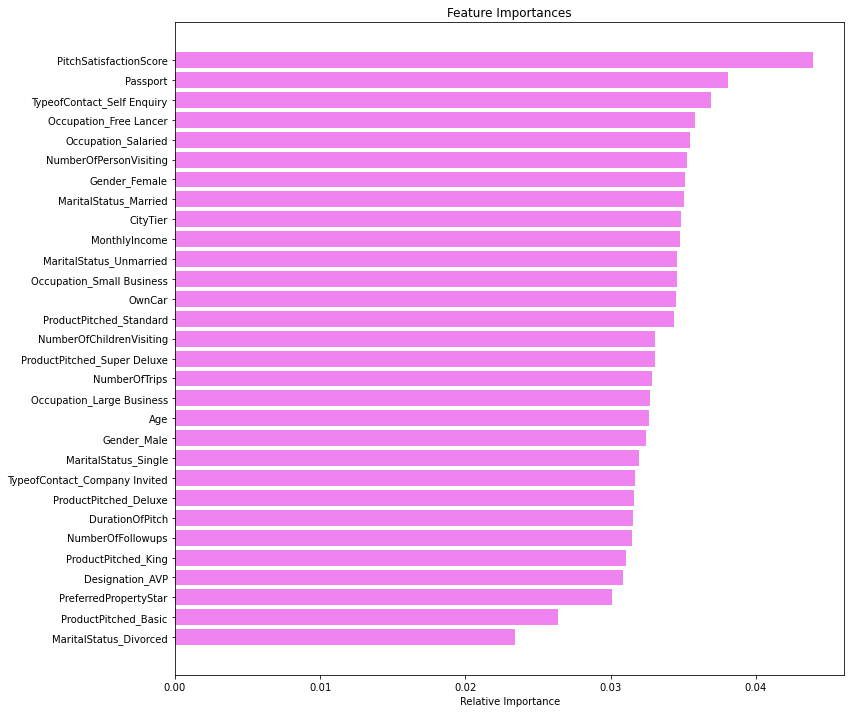

```python
#feat_imp=np.mean([tree.feature_importances_ for tree in bagging_estimator_tuned.estimators_],axis=0)
importances = np.mean([tree.feature_importances_ for tree in bagging_estimator_tuned.estimators_],axis=0)
indices = np.argsort(importances)
feature_names = list(X.columns)

plt.figure(figsize=(12,12))
plt.title('Feature Importances')
plt.barh(range(len(indices)), importances[indices], color='violet', align='center')
plt.yticks(range(len(indices)), [feature_names[i] for i in indices])
plt.xlabel('Relative Importance')
plt.show()
```

## Observations:

- According to the tuned bagging classifier with high recall, PitchSatisfactionScore, Passport and TypeofContact_SelfEnquiry are top three features that contribute to a sales pitch getting converted to a real sale.

## Boosting Classifiers

- We are going to build 3 ensemble models here - AdaBoost Classifier, Gradient Boosting Classifier and XGBoost Classifier.
- First, let's build these models with default parameters and then use hyperparameter tuning to optimize the model performance.
- We will calculate all three metrics - Accuracy, Precision and Recall but the metric of interest here is recall.
- `Recall` - It gives the ratio of True positives to Actual positives, so high Recall implies low false negatives, i.e. low chances of predicting a customer as non customer.

```python
 #To install xgboost library use - !pip install xgboost
```

[output not shown]

```python
from xgboost import XGBClassifier
```

### AdaBoost Classifier

```python
abc = AdaBoostClassifier(random_state=1)
abc.fit(X_train,y_train)
```

```
AdaBoostClassifier(random_state=1)
```

```python
#Using above defined function to get accuracy, recall and precision on train and test set
abc_score=get_metrics_score(abc)
```

```
Accuracy on training set :  0.8516451233842538
Accuracy on test set :  0.8553803975325566
Recall on training set :  0.3582554517133956
Recall on test set :  0.37454545454545457
Precision on training set :  0.7120743034055728
Precision on test set :  0.7253521126760564
```

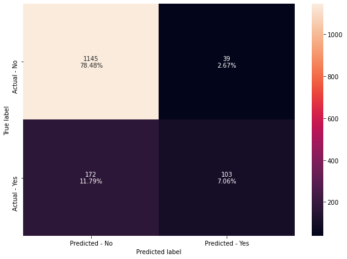

```python
make_confusion_matrix(abc,y_test)
```

### Gradient Boosting Classifier

```python
gbc = GradientBoostingClassifier(random_state=1)
gbc.fit(X_train,y_train)
```

```
GradientBoostingClassifier(random_state=1)
```

```python
#Using above defined function to get accuracy, recall and precision on train and test set
gbc_score=get_metrics_score(gbc)
```

```
Accuracy on training set :  0.886310223266745
Accuracy on test set :  0.8786840301576422
Recall on training set :  0.4735202492211838
Recall on test set :  0.44363636363636366
Precision on training set :  0.8611898016997167
Precision on test set :  0.8356164383561644
```

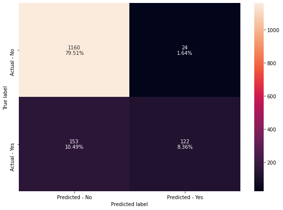

```python
make_confusion_matrix(gbc,y_test)
```

### XGBoost Classifier

```python
xgb = XGBClassifier(random_state=1,enable_categorical=True)
xgb.fit(X_train,y_train)
```

[output not shown]

```
XGBClassifier(base_score=0.5, booster='gbtree', colsample_bylevel=1,
              colsample_bynode=1, colsample_bytree=1, enable_categorical=True,
              gamma=0, gpu_id=-1, importance_type='gain',
              interaction_constraints='', learning_rate=0.300000012,
              max_delta_step=0, max_depth=6, min_child_weight=1, missing=nan,
              monotone_constraints='()', n_estimators=100, n_jobs=12,
              num_parallel_tree=1, random_state=1, reg_alpha=0, reg_lambda=1,
              scale_pos_weight=1, subsample=1, tree_method='exact',
              validate_parameters=1, verbosity=None)
```

```python
#Using above defined function to get accuracy, recall and precision on train and test set
xgb_score=get_metrics_score(xgb)
```

```
Accuracy on training set :  0.9997062279670975
Accuracy on test set :  0.934201507882111
Recall on training set :  0.9984423676012462
Recall on test set :  0.7090909090909091
Precision on training set :  1.0
Precision on test set :  0.9241706161137441
```

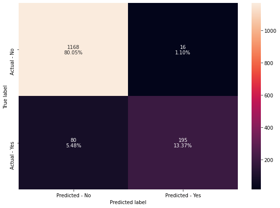

```python
make_confusion_matrix(xgb,y_test)
```

## Observations:

**With default parameters:**

## Hyperparameter Tuning

### AdaBoost Classifier

- An AdaBoost classifier is a meta-estimator that begins by fitting a classifier on the original dataset and then fits additional copies of the classifier on the same dataset but where the weights of incorrectly classified instances are adjusted such that subsequent classifiers focus more on difficult cases.
- Some important hyperparamters are:
  - base_estimator: The base estimator from which the boosted ensemble is built. By default the base estimator is a decision tree with max_depth=1
  - n_estimators: The maximum number of estimators at which boosting is terminated. Default value is 50.
  - learning_rate: Learning rate shrinks the contribution of each classifier by learning_rate. There is a trade-off between learning_rate and n_estimators.

```python
# Choose the type of classifier.
abc_tuned = AdaBoostClassifier(random_state=1)

# Grid of parameters to choose from
## add from article
parameters = {
    #Let's try different max_depth for base_estimator
    "base_estimator":[DecisionTreeClassifier(max_depth=1),DecisionTreeClassifier(max_depth=2),DecisionTreeClassifier(max_depth=3),DecisionTreeClassifier(max_depth=4)],
    "n_estimators": np.arange(10,110,10),
    #"learning_rate":np.arange(0.1,2,0.1)
    "learning_rate": [1, 0.1, 0.5, 0.01]
}

# Type of scoring used to compare parameter combinations
acc_scorer = metrics.make_scorer(metrics.recall_score)

# Run the grid search
grid_obj = GridSearchCV(abc_tuned, parameters, scoring=acc_scorer,cv=5)
grid_obj = grid_obj.fit(X_train, y_train)

# Set the clf to the best combination of parameters
abc_tuned = grid_obj.best_estimator_

# Fit the best algorithm to the data.
abc_tuned.fit(X_train, y_train)
```

```
AdaBoostClassifier(base_estimator=DecisionTreeClassifier(max_depth=4),
                   learning_rate=1, n_estimators=90, random_state=1)
```

```python
#Using above defined function to get accuracy, recall and precision on train and test set
abc_tuned_score=get_metrics_score(abc_tuned)
```

```
Accuracy on training set :  1.0
Accuracy on test set :  0.9019876627827279
Recall on training set :  1.0
Recall on test set :  0.6909090909090909
Precision on training set :  1.0
Precision on test set :  0.7661290322580645
```

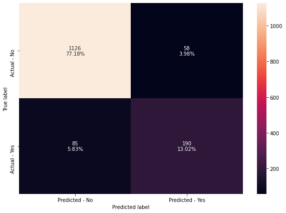

```python
make_confusion_matrix(abc_tuned,y_test)
```

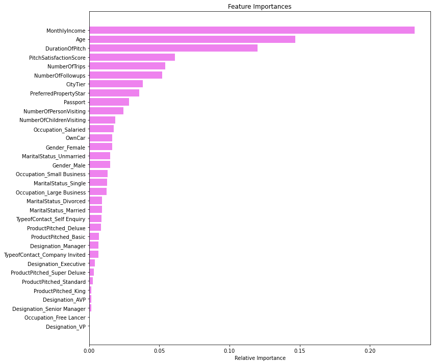

```python
importances = abc_tuned.feature_importances_
indices = np.argsort(importances)
feature_names = list(X.columns)

plt.figure(figsize=(12,12))
plt.title('Feature Importances')
plt.barh(range(len(indices)), importances[indices], color='violet', align='center')
plt.yticks(range(len(indices)), [feature_names[i] for i in indices])
plt.xlabel('Relative Importance')
plt.show()
```

### Observations:

- The model is slightly overfitting the train data as train accuracy is 100% while test accuracy is 90%
- The model has low test recall. This implies that the model is not good at identifying customers.
- Confusion Matrix shows that FN is not very high (5.83%) which is good, as well as FP (3.98%)
- MonthlyIncome is the most important feature as per the tuned AdaBoost model.
- Let's see how well hypertuning works in gbc and xgb classifer.

### Gradient Boosting Classifier

- Most of the hyperparameters available are same as random forest classifier.
- init: An estimator object that is used to compute the initial predictions. If ‘zero’, the initial raw predictions are set to zero. By default, a DummyEstimator predicting the classes priors is used.
- There is no class_weights parameter in gradient boosting.

**Let's try using AdaBoost classifier as the estimator for initial predictions**

```python
gbc_init = GradientBoostingClassifier(init=AdaBoostClassifier(random_state=1),random_state=1)
gbc_init.fit(X_train,y_train)
```

```
GradientBoostingClassifier(init=AdaBoostClassifier(random_state=1),
                           random_state=1)
```

```python
#Using above defined function to get accuracy, recall and precision on train and test set
gbc_init_score=get_metrics_score(gbc_init)
```

```
Accuracy on training set :  0.88572267920094
Accuracy on test set :  0.8800548320767649
Recall on training set :  0.46417445482866043
Recall on test set :  0.44363636363636366
Precision on training set :  0.8688046647230321
Precision on test set :  0.8472222222222222
```

**As compared to the model with default parameters:**

- Test accuracy and test recall are same as gbc with default params.
- Since we got similar results, lets try to tune this and see if we get better results.

```python
# Choose the type of classifier.
gbc_tuned = GradientBoostingClassifier(init=AdaBoostClassifier(random_state=1),random_state=1)

# Grid of parameters to choose from
## add from article
parameters = {
    "n_estimators": [100,150,200,250,300],
    "subsample":[0.8,0.9,1],
    "max_features":[0.7,0.8,0.9,1]
}

# Type of scoring used to compare parameter combinations
acc_scorer = metrics.make_scorer(metrics.recall_score)

# Run the grid search
grid_obj = GridSearchCV(gbc_tuned, parameters, scoring=acc_scorer,cv=5)
grid_obj = grid_obj.fit(X_train, y_train)

# Set the clf to the best combination of parameters
gbc_tuned = grid_obj.best_estimator_

# Fit the best algorithm to the data.
gbc_tuned.fit(X_train, y_train)
```

```
GradientBoostingClassifier(init=AdaBoostClassifier(random_state=1),
                           max_features=0.9, n_estimators=300, random_state=1,
                           subsample=0.8)
```

```python
#Using above defined function to get accuracy, recall and precision on train and test set
gbc_tuned_score=get_metrics_score(gbc_tuned)
```

```
Accuracy on training set :  0.9309635722679201
Accuracy on test set :  0.8923920493488691
Recall on training set :  0.6728971962616822
Recall on test set :  0.5381818181818182
Precision on training set :  0.9452954048140044
Precision on test set :  0.8314606741573034
```

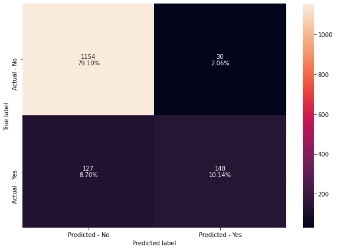

```python
make_confusion_matrix(gbc_tuned,y_test)
```

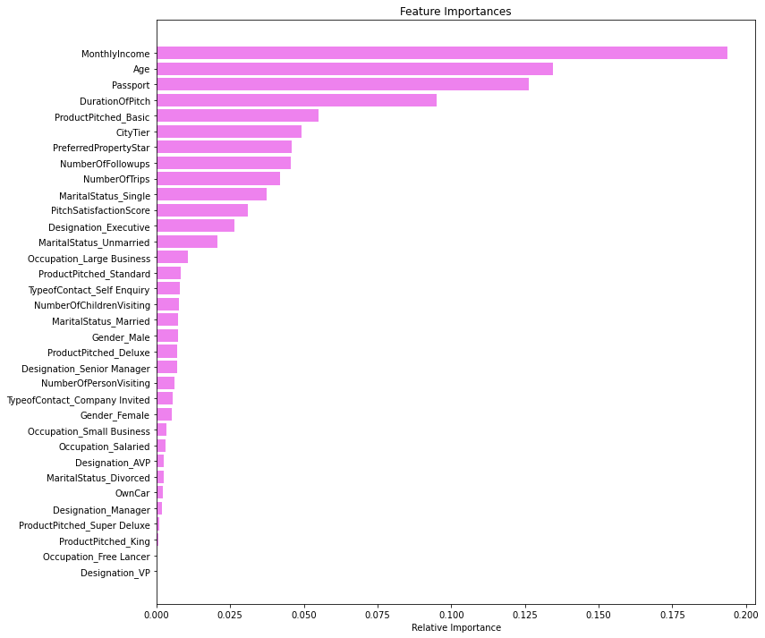

```python
importances = gbc_tuned.feature_importances_
indices = np.argsort(importances)
feature_names = list(X.columns)

plt.figure(figsize=(12,12))
plt.title('Feature Importances')
plt.barh(range(len(indices)), importances[indices], color='violet', align='center')
plt.yticks(range(len(indices)), [feature_names[i] for i in indices])
plt.xlabel('Relative Importance')
plt.show()
```

### Observations:

- Train and Test accuracy has increased.
- Train and Test recall has also increased, but its still not that great.
- Training precision has increased, but test precision has decreased.
- The model performace has not increased by much.
- It is slightly better at identifying customers as compared to the default gbc model.
- MonthlyIncome is the most important feature, followed by Age and Passport, as per the tuned gradient boosting model.
- Let's see if the XGBoost tuned classifier performs any better.

### XGBoost Classifier Hypertuning

XGBoost hypertuning params:

- scale_pos_weight:Control the balance of positive and negative weights, useful for unbalanced classes. It has range from 0 to $\infty$.
- subsample: Corresponds to the fraction of observations (the rows) to subsample at each step. By default it is set to 1 meaning that we use all rows.
- colsample_bytree: Corresponds to the fraction of features (the columns) to use.
- colsample_bylevel: The subsample ratio of columns for each level. Columns are subsampled from the set of columns chosen for the current tree.
- colsample_bynode: The subsample ratio of columns for each node (split). Columns are subsampled from the set of columns chosen for the current level.
- max_depth: is the maximum number of nodes allowed from the root to the farthest leaf of a tree.
- learning_rate/eta: Makes the model more robust by shrinking the weights on each step.
- gamma: A node is split only when the resulting split gives a positive reduction in the loss function. Gamma specifies the minimum loss reduction required to make a split.

```python
# Choose the type of classifier.
xgb_tuned = XGBClassifier(random_state=1, eval_metric='logloss')

# Grid of parameters to choose from
## add from
parameters = {
    "n_estimators": np.arange(10,100,20),
    "scale_pos_weight":[0,1,2,5],
    "subsample":[0.5,0.7,0.9,1],
    "learning_rate":[0.01,0.1,0.2,0.05],
    "gamma":[0,1,3],
    "colsample_bytree":[0.5,0.7,0.9,1],
    "colsample_bylevel":[0.5,0.7,0.9,1]
}

# Type of scoring used to compare parameter combinations
acc_scorer = metrics.make_scorer(metrics.recall_score)

# Run the grid search
grid_obj = GridSearchCV(xgb_tuned, parameters,scoring=acc_scorer,cv=5)
grid_obj = grid_obj.fit(X_train, y_train)

# Set the clf to the best combination of parameters
xgb_tuned = grid_obj.best_estimator_

# Fit the best algorithm to the data.
xgb_tuned.fit(X_train, y_train)
```

```
XGBClassifier(base_score=0.5, booster='gbtree', colsample_bylevel=0.9,
              colsample_bynode=1, colsample_bytree=1, eval_metric='logloss',
              gamma=3, gpu_id=-1, importance_type='gain',
              interaction_constraints='', learning_rate=0.05, max_delta_step=0,
              max_depth=6, min_child_weight=1, missing=nan,
              monotone_constraints='()', n_estimators=90, n_jobs=12,
              num_parallel_tree=1, random_state=1, reg_alpha=0, reg_lambda=1,
              scale_pos_weight=5, subsample=1, tree_method='exact',
              validate_parameters=1, verbosity=None)
```

```python
#Using above defined function to get accuracy, recall and precision on train and test set
xgb_tuned_score=get_metrics_score(xgb_tuned)
```

```
Accuracy on training set :  0.9312573443008225
Accuracy on test set :  0.8725154215215901
Recall on training set :  0.9626168224299065
Recall on test set :  0.8363636363636363
Precision on training set :  0.7463768115942029
Precision on test set :  0.6199460916442049
```

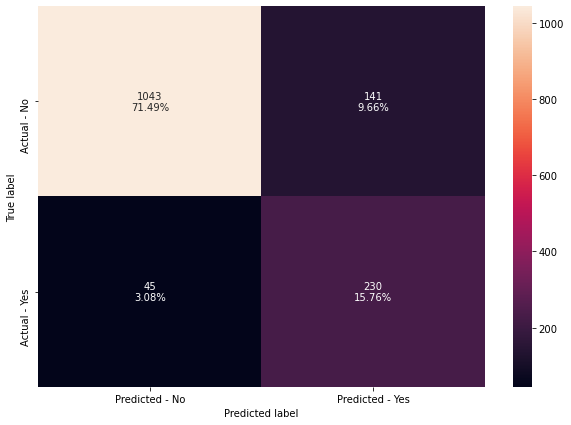

```python
make_confusion_matrix(xgb_tuned,y_test)
```

### Observations:

```python
# importance of features in the tree building ( The importance of a feature is computed as the
#(normalized) total reduction of the criterion brought by that feature. It is also known as the Gini importance )

print(pd.DataFrame(xgb_tuned.feature_importances_, columns = ["Imp"], index = X_train.columns).sort_values(by = 'Imp', ascending = False))
```

```
                                    Imp
Passport                       0.120601
ProductPitched_Basic           0.090540
CityTier                       0.042003
MaritalStatus_Married          0.038726
MaritalStatus_Single           0.035898
Designation_Manager            0.034587
Gender_Male                    0.031702
Designation_Executive          0.030864
PreferredPropertyStar          0.030029
Age                            0.028851
MaritalStatus_Unmarried        0.027683
Occupation_Large Business      0.027542
ProductPitched_Standard        0.026272
Occupation_Salaried            0.025397
OwnCar                         0.025125
DurationOfPitch                0.024838
NumberOfFollowups              0.024766
PitchSatisfactionScore         0.024668
Designation_VP                 0.023820
ProductPitched_Super Deluxe    0.023479
NumberOfTrips                  0.023453
Designation_Senior Manager     0.022884
MonthlyIncome                  0.021801
MaritalStatus_Divorced         0.021510
ProductPitched_King            0.021471
Designation_AVP                0.020899
TypeofContact_Company Invited  0.020412
Gender_Female                  0.020073
ProductPitched_Deluxe          0.020010
Occupation_Small Business      0.019651
TypeofContact_Self Enquiry     0.018442
NumberOfPersonVisiting         0.017111
NumberOfChildrenVisiting       0.014892
Occupation_Free Lancer         0.000000
```

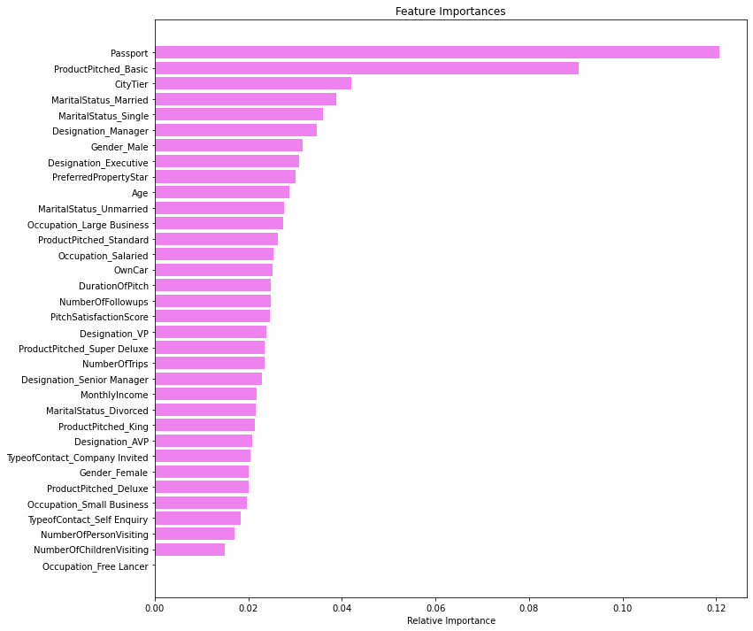

```python
importances = xgb_tuned.feature_importances_
indices = np.argsort(importances)
feature_names = list(X.columns)

plt.figure(figsize=(12,12))
plt.title('Feature Importances')
plt.barh(range(len(indices)), importances[indices], color='violet', align='center')
plt.yticks(range(len(indices)), [feature_names[i] for i in indices])
plt.xlabel('Relative Importance')
plt.show()
```

### Observations:

- Passport (having passport) is the most important feature as per XGBoost model unlike AdaBoost and Gradient Boosting, where the most important feature is the MonthlyIncome.
- Followed by Passport, ProductPitched_Basic is another features that contributes a lot.
- Other features like CityTier, MaritalStatus, Designation etc are close to each other.

## Stacking Classifier

For stacking classifier, we will combine couple of weak models:

1. Default Bagging Classifier
2. Random Forest Default Classifier
3. Random Forest Tuned Classifier
4. Random Forest Weighted Classifier
5. Tuned AdaBooster Classifier
6. Tuned Gradient Booster Classifier

```python
estimators=[('Bagging Default',bagging_estimator),('RF Default',rf_estimator),
           ('Tuned RF',rf_estimator_tuned),('RF Weighted',rf_estimator_weighted),
           ('AdaBooster Tuned',abc_tuned),('GBC Tuned',gbc_tuned)]


final_estimator=XGBClassifier(random_state=1)
```

```python
stacking_estimator=StackingClassifier(estimators=estimators, final_estimator=final_estimator,stack_method='predict_proba',cv=3)



stacking_estimator.fit(X_train,y_train)
```

```
[23:45:30] WARNING: /Users/travis/build/dmlc/xgboost/src/learner.cc:1095: Starting in XGBoost 1.3.0, the default evaluation metric used with the objective 'binary:logistic' was changed from 'error' to 'logloss'. Explicitly set eval_metric if you'd like to restore the old behavior.
```

```
StackingClassifier(cv=3,
                   estimators=[('Bagging Default',
                                BaggingClassifier(random_state=1)),
                               ('RF Default',
                                RandomForestClassifier(random_state=1)),
                               ('Tuned RF',
                                RandomForestClassifier(max_features=0.6000000000000001,
                                                       max_samples=0.6000000000000001,
                                                       min_samples_leaf=5,
                                                       n_estimators=200,
                                                       random_state=1)),
                               ('RF Weighted',
                                RandomForestClassifier(class_weight={0: 0.2,
                                                                     1...
                                                 interaction_constraints=None,
                                                 learning_rate=None,
                                                 max_delta_step=None,
                                                 max_depth=None,
                                                 min_child_weight=None,
                                                 missing=nan,
                                                 monotone_constraints=None,
                                                 n_estimators=100, n_jobs=None,
                                                 num_parallel_tree=None,
                                                 random_state=1, reg_alpha=None,
                                                 reg_lambda=None,
                                                 scale_pos_weight=None,
                                                 subsample=None,
                                                 tree_method=None,
                                                 validate_parameters=None,
                                                 verbosity=None),
                   stack_method='predict_proba')
```

```python
#Using above defined function to get accuracy, recall and precision on train and test set
c=get_metrics_score(stacking_estimator)
```

```
Accuracy on training set :  1.0
Accuracy on test set :  0.9362577107607951
Recall on training set :  1.0
Recall on test set :  0.8145454545454546
Precision on training set :  1.0
Precision on test set :  0.8421052631578947
```

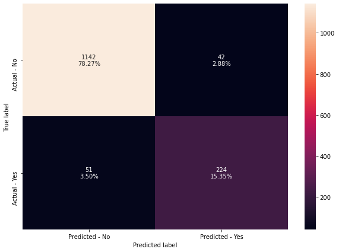

```python
make_confusion_matrix(stacking_estimator,y_test)
```

## Comparing all Boosting models

```python
# defining list of models
models = [abc, abc_tuned, gbc, gbc_init, gbc_tuned, xgb, xgb_tuned,stacking_estimator]

# defining empty lists to add train and test results
acc_train = []
acc_test = []
recall_train = []
recall_test = []
precision_train = []
precision_test = []

# looping through all the models to get the accuracy, precall and precision scores
for model in models:
    j = get_metrics_score(model,False)
    acc_train.append(np.round(j[0],2))
    acc_test.append(np.round(j[1],2))
    recall_train.append(np.round(j[2],2))
    recall_test.append(np.round(j[3],2))
    precision_train.append(np.round(j[4],2))
    precision_test.append(np.round(j[5],2))
```

```python
comparison_frame = pd.DataFrame({'Model':['AdaBoost with default paramters','AdaBoost Tuned',
                                          'Gradient Boosting with default parameters','Gradient Boosting with init=AdaBoost',
                                          'Gradient Boosting Tuned','XGBoost with default parameters','XGBoost Tuned','Stacking Estimator'],
                                          'Train_Accuracy': acc_train,'Test_Accuracy': acc_test,
                                          'Train_Recall':recall_train,'Test_Recall':recall_test,
                                          'Train_Precision':precision_train,'Test_Precision':precision_test})
comparison_frame
```

|  | Model | Train_Accuracy | Test_Accuracy | Train_Recall | Test_Recall | Train_Precision | Test_Precision |
| --- | --- | --- | --- | --- | --- | --- | --- |
| 0 | AdaBoost with default paramters | 0.85 | 0.86 | 0.36 | 0.37 | 0.71 | 0.73 |
| 1 | AdaBoost Tuned | 1.00 | 0.90 | 1.00 | 0.69 | 1.00 | 0.77 |
| 2 | Gradient Boosting with default parameters | 0.89 | 0.88 | 0.47 | 0.44 | 0.86 | 0.84 |
| 3 | Gradient Boosting with init=AdaBoost | 0.89 | 0.88 | 0.46 | 0.44 | 0.87 | 0.85 |
| 4 | Gradient Boosting Tuned | 0.93 | 0.89 | 0.67 | 0.54 | 0.95 | 0.83 |
| 5 | XGBoost with default parameters | 1.00 | 0.93 | 1.00 | 0.71 | 1.00 | 0.92 |
| 6 | XGBoost Tuned | 0.93 | 0.87 | 0.96 | 0.84 | 0.75 | 0.62 |
| 7 | Stacking Estimator | 1.00 | 0.94 | 1.00 | 0.81 | 1.00 | 0.84 |

## Actionable Insights & Recommendations

- Based on the XGBoost tuned model's important features, the customer profile should indicate that:
  - the customer has a Passport,
  - they can be either married or Single
  - they can be Manager in their organization
- With EDA on passport, we saw that only 29.2% people from current dataset have Passport. Since passport is one of the important features, the Tourism company can diversify the new “Wellness Tourism Package” to both National and International destinations and pitch right product to people based on whether they have Passport or not.
- Another key insight is to target more Single and Married people and see if they would be interested in Wellness package.
- As we saw that Basic package is one of the most popular one and also one of the important features, it will be good to see if the Travel company can design the new Wellness package inline with the Basic package.
- Out of all the travel packages, Basic one sounds like a Budget friendly package (this is not mentioned, so its an assumption) and it seems that Budget is one of the important feature that customers look for when they are planning to buy a travel package, it will be good if Travel company can look at making the Wellness Package budget friendly or have different levels within the package like Wellness-Basic, Wellness- Deluxe etc to attract diverse customers.
- Travel Tourism company can use the high performing (High Recall) XGBoost Tuned model when they are prioritizing converting pitches into sales i.e. getting new customers. Once they have acquired the desired number of cutomers, and want to look at reducing the Advertising Cost and reduce False Positives Stacking Classifier can be used.